# Risk Factor Analysis

## Outcome Variable

**Outcome Variable:** stunted

## Predictor Variables

**Intervention Variable:** fhtcm

**Adjustment Set:**

unadjusted

## Stratifying Variables

The analysis was stratified on these variable(s):

- agecat
- studyid
- country

## Data Summary

| agecat | studyid | country | A | n | nA | nAY0 | nAY1 |
| --- | --- | --- | --- | --- | --- | --- | --- |
| Birth | ki1000304b-SAS-CompFeed | INDIA | [160-170) | 42 | 30 | 23 | 7 |
| Birth | ki1000304b-SAS-CompFeed | INDIA | <160 | 42 | 6 | 4 | 2 |
| Birth | ki1000304b-SAS-CompFeed | INDIA | >=170 | 42 | 6 | 3 | 3 |
| Birth | ki1101329-Keneba | GAMBIA | [160-170) | 1165 | 631 | 598 | 33 |
| Birth | ki1101329-Keneba | GAMBIA | <160 | 1165 | 27 | 24 | 3 |
| Birth | ki1101329-Keneba | GAMBIA | >=170 | 1165 | 507 | 485 | 22 |
| Birth | ki1119695-PROBIT | BELARUS | [160-170) | 6247 | 724 | 722 | 2 |
| Birth | ki1119695-PROBIT | BELARUS | <160 | 6247 | 23 | 23 | 0 |
| Birth | ki1119695-PROBIT | BELARUS | >=170 | 6247 | 5500 | 5482 | 18 |
| Birth | ki1135781-COHORTS | GUATEMALA | [160-170) | 91 | 53 | 51 | 2 |
| Birth | ki1135781-COHORTS | GUATEMALA | <160 | 91 | 32 | 30 | 2 |
| Birth | ki1135781-COHORTS | GUATEMALA | >=170 | 91 | 6 | 4 | 2 |
| 3 months | ki1000304b-SAS-CompFeed | INDIA | [160-170) | 224 | 136 | 103 | 33 |
| 3 months | ki1000304b-SAS-CompFeed | INDIA | <160 | 224 | 29 | 17 | 12 |
| 3 months | ki1000304b-SAS-CompFeed | INDIA | >=170 | 224 | 59 | 46 | 13 |
| 3 months | ki1000304b-SAS-FoodSuppl | INDIA | [160-170) | 92 | 59 | 40 | 19 |
| 3 months | ki1000304b-SAS-FoodSuppl | INDIA | <160 | 92 | 22 | 11 | 11 |
| 3 months | ki1000304b-SAS-FoodSuppl | INDIA | >=170 | 92 | 11 | 6 | 5 |
| 3 months | ki1101329-Keneba | GAMBIA | [160-170) | 1562 | 859 | 719 | 140 |
| 3 months | ki1101329-Keneba | GAMBIA | <160 | 1562 | 36 | 30 | 6 |
| 3 months | ki1101329-Keneba | GAMBIA | >=170 | 1562 | 667 | 595 | 72 |
| 3 months | ki1119695-PROBIT | BELARUS | [160-170) | 6234 | 721 | 655 | 66 |
| 3 months | ki1119695-PROBIT | BELARUS | <160 | 6234 | 23 | 21 | 2 |
| 3 months | ki1119695-PROBIT | BELARUS | >=170 | 6234 | 5490 | 5188 | 302 |
| 3 months | ki1135781-COHORTS | GUATEMALA | [160-170) | 140 | 75 | 53 | 22 |
| 3 months | ki1135781-COHORTS | GUATEMALA | <160 | 140 | 53 | 25 | 28 |
| 3 months | ki1135781-COHORTS | GUATEMALA | >=170 | 140 | 12 | 7 | 5 |
| 6 months | ki1000304b-SAS-CompFeed | INDIA | [160-170) | 218 | 133 | 98 | 35 |
| 6 months | ki1000304b-SAS-CompFeed | INDIA | <160 | 218 | 26 | 18 | 8 |
| 6 months | ki1000304b-SAS-CompFeed | INDIA | >=170 | 218 | 59 | 50 | 9 |

[output cut: 66 more lines]

The following strata were considered:

- agecat: 12 months, studyid: ki1000304b-SAS-CompFeed, country: INDIA
- agecat: 12 months, studyid: ki1000304b-SAS-FoodSuppl, country: INDIA
- agecat: 12 months, studyid: ki1101329-Keneba, country: GAMBIA
- agecat: 12 months, studyid: ki1119695-PROBIT, country: BELARUS
- agecat: 12 months, studyid: ki1135781-COHORTS, country: GUATEMALA
- agecat: 18 months, studyid: ki1000304b-SAS-CompFeed, country: INDIA
- agecat: 18 months, studyid: ki1000304b-SAS-FoodSuppl, country: INDIA
- agecat: 18 months, studyid: ki1101329-Keneba, country: GAMBIA
- agecat: 18 months, studyid: ki1119695-PROBIT, country: BELARUS
- agecat: 18 months, studyid: ki1135781-COHORTS, country: GUATEMALA
- agecat: 24 months, studyid: ki1101329-Keneba, country: GAMBIA
- agecat: 24 months, studyid: ki1119695-PROBIT, country: BELARUS
- agecat: 24 months, studyid: ki1135781-COHORTS, country: GUATEMALA
- agecat: 3 months, studyid: ki1000304b-SAS-CompFeed, country: INDIA
- agecat: 3 months, studyid: ki1000304b-SAS-FoodSuppl, country: INDIA
- agecat: 3 months, studyid: ki1101329-Keneba, country: GAMBIA
- agecat: 3 months, studyid: ki1119695-PROBIT, country: BELARUS
- agecat: 3 months, studyid: ki1135781-COHORTS, country: GUATEMALA
- agecat: 6 months, studyid: ki1000304b-SAS-CompFeed, country: INDIA
- agecat: 6 months, studyid: ki1000304b-SAS-FoodSuppl, country: INDIA
- agecat: 6 months, studyid: ki1101329-Keneba, country: GAMBIA
- agecat: 6 months, studyid: ki1119695-PROBIT, country: BELARUS
- agecat: 6 months, studyid: ki1135781-COHORTS, country: GUATEMALA
- agecat: 9 months, studyid: ki1000304b-SAS-CompFeed, country: INDIA
- agecat: 9 months, studyid: ki1000304b-SAS-FoodSuppl, country: INDIA
- agecat: 9 months, studyid: ki1101329-Keneba, country: GAMBIA
- agecat: 9 months, studyid: ki1119695-PROBIT, country: BELARUS
- agecat: 9 months, studyid: ki1135781-COHORTS, country: GUATEMALA
- agecat: Birth, studyid: ki1000304b-SAS-CompFeed, country: INDIA
- agecat: Birth, studyid: ki1101329-Keneba, country: GAMBIA
- agecat: Birth, studyid: ki1119695-PROBIT, country: BELARUS
- agecat: Birth, studyid: ki1135781-COHORTS, country: GUATEMALA

### Dropped Strata

Some strata were dropped due to rare outcomes:

- agecat: Birth, studyid: ki1000304b-SAS-CompFeed, country: INDIA
- agecat: Birth, studyid: ki1101329-Keneba, country: GAMBIA
- agecat: Birth, studyid: ki1119695-PROBIT, country: BELARUS
- agecat: Birth, studyid: ki1135781-COHORTS, country: GUATEMALA
- agecat: 3 months, studyid: ki1119695-PROBIT, country: BELARUS
- agecat: 6 months, studyid: ki1119695-PROBIT, country: BELARUS
- agecat: 9 months, studyid: ki1000304b-SAS-FoodSuppl, country: INDIA
- agecat: 9 months, studyid: ki1119695-PROBIT, country: BELARUS
- agecat: 9 months, studyid: ki1135781-COHORTS, country: GUATEMALA
- agecat: 12 months, studyid: ki1000304b-SAS-FoodSuppl, country: INDIA
- agecat: 12 months, studyid: ki1119695-PROBIT, country: BELARUS
- agecat: 12 months, studyid: ki1135781-COHORTS, country: GUATEMALA
- agecat: 18 months, studyid: ki1000304b-SAS-FoodSuppl, country: INDIA
- agecat: 18 months, studyid: ki1119695-PROBIT, country: BELARUS
- agecat: 18 months, studyid: ki1135781-COHORTS, country: GUATEMALA
- agecat: 24 months, studyid: ki1119695-PROBIT, country: BELARUS

## Methods Detail

We’re interested in the causal parameters $E[Y_a]$ for all values of $a \in \mathcal{A}$. These parameters represent the mean outcome if, possibly contrary to fact, we intervened to set all units to have $A=a$. Under the randomization and positivity assumptions, these are identified by the statistical parameters $\psi_a=E_W[E_{Y|A,W}(Y|A=a,W)]$. In addition, we’re interested in the mean of $Y$, $E[Y]$ under no intervention (the observed mean). We will estimate these parameters by using SuperLearner to fit the relevant likelihood factors – $E_{Y|A,W}(Y|A=a,W)$ and $p(A=a|W)$, and then updating our likelihood fit using a joint TMLE.

For unadjusted analyses ($W=\{\}$), initial likelihoods were estimated using Lrnr_glm to estimate the simple $E(Y|A)$ and Lrnr_mean to estimate $p(A)$. For adjusted analyses, a small library containing Lrnr_glmnet, Lrnr_xgboost, and Lrnr_mean was used.

Having estimated these parameters, we will then use the delta method to estimate relative risks and attributable risks relative to a prespecified baseline level of $A$.

# Results Detail

## Results Plots

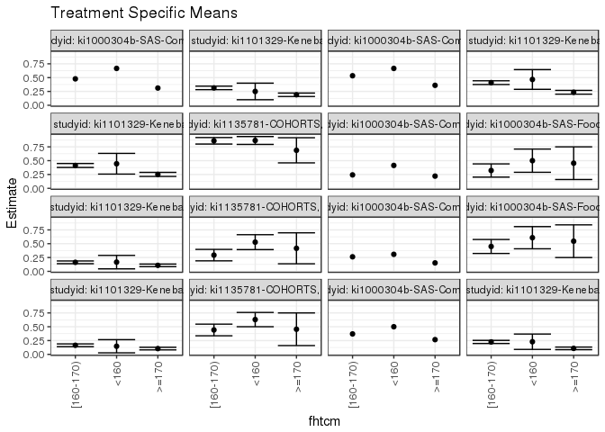

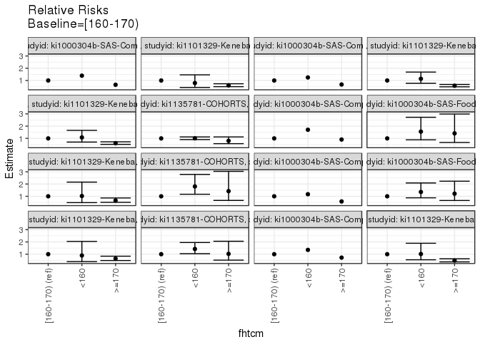

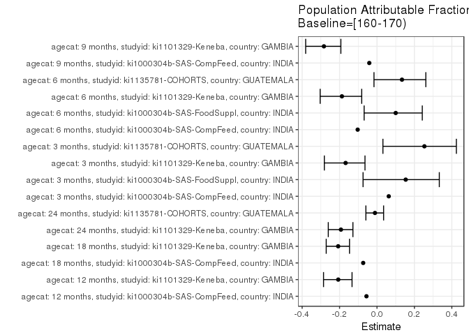

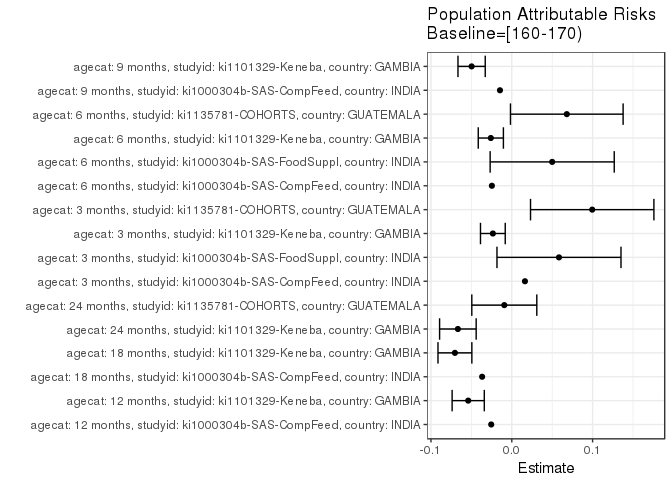

## Results Table

### Parameter: TSM

| agecat | studyid | country | intervention_level | baseline_level | estimate | ci_lower | ci_upper |
| --- | --- | --- | --- | --- | --- | --- | --- |
| 3 months | ki1000304b-SAS-CompFeed | INDIA | [160-170) | NA | 0.2426471 | NA | NA |
| 3 months | ki1000304b-SAS-CompFeed | INDIA | <160 | NA | 0.4137931 | NA | NA |
| 3 months | ki1000304b-SAS-CompFeed | INDIA | >=170 | NA | 0.2203390 | NA | NA |
| 3 months | ki1000304b-SAS-FoodSuppl | INDIA | [160-170) | NA | 0.3220339 | 0.2021530 | 0.4419148 |
| 3 months | ki1000304b-SAS-FoodSuppl | INDIA | <160 | NA | 0.5000000 | 0.2899223 | 0.7100777 |
| 3 months | ki1000304b-SAS-FoodSuppl | INDIA | >=170 | NA | 0.4545455 | 0.1586809 | 0.7504100 |
| 3 months | ki1101329-Keneba | GAMBIA | [160-170) | NA | 0.1629802 | 0.1382729 | 0.1876875 |
| 3 months | ki1101329-Keneba | GAMBIA | <160 | NA | 0.1666667 | 0.0448884 | 0.2884449 |
| 3 months | ki1101329-Keneba | GAMBIA | >=170 | NA | 0.1079460 | 0.0843889 | 0.1315032 |
| 3 months | ki1135781-COHORTS | GUATEMALA | [160-170) | NA | 0.2933333 | 0.1899234 | 0.3967432 |
| 3 months | ki1135781-COHORTS | GUATEMALA | <160 | NA | 0.5283019 | 0.3934243 | 0.6631795 |
| 3 months | ki1135781-COHORTS | GUATEMALA | >=170 | NA | 0.4166667 | 0.1367254 | 0.6966079 |
| 6 months | ki1000304b-SAS-CompFeed | INDIA | [160-170) | NA | 0.2631579 | NA | NA |
| 6 months | ki1000304b-SAS-CompFeed | INDIA | <160 | NA | 0.3076923 | NA | NA |
| 6 months | ki1000304b-SAS-CompFeed | INDIA | >=170 | NA | 0.1525424 | NA | NA |
| 6 months | ki1000304b-SAS-FoodSuppl | INDIA | [160-170) | NA | 0.4500000 | 0.3234441 | 0.5765559 |
| 6 months | ki1000304b-SAS-FoodSuppl | INDIA | <160 | NA | 0.6086957 | 0.4081727 | 0.8092186 |
| 6 months | ki1000304b-SAS-FoodSuppl | INDIA | >=170 | NA | 0.5454545 | 0.2496246 | 0.8412845 |
| 6 months | ki1101329-Keneba | GAMBIA | [160-170) | NA | 0.1642512 | 0.1390066 | 0.1894958 |
| 6 months | ki1101329-Keneba | GAMBIA | <160 | NA | 0.1470588 | 0.0279737 | 0.2661439 |
| 6 months | ki1101329-Keneba | GAMBIA | >=170 | NA | 0.1047766 | 0.0812062 | 0.1283470 |
| 6 months | ki1135781-COHORTS | GUATEMALA | [160-170) | NA | 0.4418605 | 0.3365538 | 0.5471671 |
| 6 months | ki1135781-COHORTS | GUATEMALA | <160 | NA | 0.6296296 | 0.5004022 | 0.7588571 |
| 6 months | ki1135781-COHORTS | GUATEMALA | >=170 | NA | 0.4545455 | 0.1593141 | 0.7497768 |
| 9 months | ki1000304b-SAS-CompFeed | INDIA | [160-170) | NA | 0.3700787 | NA | NA |
| 9 months | ki1000304b-SAS-CompFeed | INDIA | <160 | NA | 0.5000000 | NA | NA |
| 9 months | ki1000304b-SAS-CompFeed | INDIA | >=170 | NA | 0.2666667 | NA | NA |
| 9 months | ki1101329-Keneba | GAMBIA | [160-170) | NA | 0.2250000 | 0.1967517 | 0.2532483 |
| 9 months | ki1101329-Keneba | GAMBIA | <160 | NA | 0.2285714 | 0.0894113 | 0.3677316 |
| 9 months | ki1101329-Keneba | GAMBIA | >=170 | NA | 0.1085627 | 0.0847128 | 0.1324126 |
| 12 months | ki1000304b-SAS-CompFeed | INDIA | [160-170) | NA | 0.4779412 | NA | NA |
| 12 months | ki1000304b-SAS-CompFeed | INDIA | <160 | NA | 0.6666667 | NA | NA |
| 12 months | ki1000304b-SAS-CompFeed | INDIA | >=170 | NA | 0.3114754 | NA | NA |
| 12 months | ki1101329-Keneba | GAMBIA | [160-170) | NA | 0.3142857 | 0.2822057 | 0.3463657 |
| 12 months | ki1101329-Keneba | GAMBIA | <160 | NA | 0.2500000 | 0.0999197 | 0.4000803 |
| 12 months | ki1101329-Keneba | GAMBIA | >=170 | NA | 0.1898527 | 0.1587450 | 0.2209604 |
| 18 months | ki1000304b-SAS-CompFeed | INDIA | [160-170) | NA | 0.5343511 | NA | NA |
| 18 months | ki1000304b-SAS-CompFeed | INDIA | <160 | NA | 0.6666667 | NA | NA |
| 18 months | ki1000304b-SAS-CompFeed | INDIA | >=170 | NA | 0.3606557 | NA | NA |
| 18 months | ki1101329-Keneba | GAMBIA | [160-170) | NA | 0.4094775 | 0.3758704 | 0.4430847 |
| 18 months | ki1101329-Keneba | GAMBIA | <160 | NA | 0.4666667 | 0.2880835 | 0.6452498 |
| 18 months | ki1101329-Keneba | GAMBIA | >=170 | NA | 0.2347973 | 0.2006409 | 0.2689537 |
| 24 months | ki1101329-Keneba | GAMBIA | [160-170) | NA | 0.4128944 | 0.3771400 | 0.4486488 |
| 24 months | ki1101329-Keneba | GAMBIA | <160 | NA | 0.4444444 | 0.2569423 | 0.6319466 |
| 24 months | ki1101329-Keneba | GAMBIA | >=170 | NA | 0.2513863 | 0.2148170 | 0.2879556 |
| 24 months | ki1135781-COHORTS | GUATEMALA | [160-170) | NA | 0.8592593 | 0.8004752 | 0.9180434 |
| 24 months | ki1135781-COHORTS | GUATEMALA | <160 | NA | 0.8651685 | 0.7940626 | 0.9362745 |
| 24 months | ki1135781-COHORTS | GUATEMALA | >=170 | NA | 0.6875000 | 0.4599085 | 0.9150915 |

### Parameter: E(Y)

| agecat | studyid | country | intervention_level | baseline_level | estimate | ci_lower | ci_upper |
| --- | --- | --- | --- | --- | --- | --- | --- |
| 3 months | ki1000304b-SAS-CompFeed | INDIA | NA | NA | 0.2589286 | NA | NA |
| 3 months | ki1000304b-SAS-FoodSuppl | INDIA | NA | NA | 0.3804348 | 0.2806852 | 0.4801843 |
| 3 months | ki1101329-Keneba | GAMBIA | NA | NA | 0.1395647 | 0.1223740 | 0.1567554 |
| 3 months | ki1135781-COHORTS | GUATEMALA | NA | NA | 0.3928571 | 0.3116670 | 0.4740473 |
| 6 months | ki1000304b-SAS-CompFeed | INDIA | NA | NA | 0.2385321 | NA | NA |
| 6 months | ki1000304b-SAS-FoodSuppl | INDIA | NA | NA | 0.5000000 | 0.3983806 | 0.6016194 |
| 6 months | ki1101329-Keneba | GAMBIA | NA | NA | 0.1383190 | 0.1209060 | 0.1557320 |
| 6 months | ki1135781-COHORTS | GUATEMALA | NA | NA | 0.5099338 | 0.4299344 | 0.5899332 |
| 9 months | ki1000304b-SAS-CompFeed | INDIA | NA | NA | 0.3554502 | NA | NA |
| 9 months | ki1101329-Keneba | GAMBIA | NA | NA | 0.1752780 | 0.1562144 | 0.1943415 |
| 12 months | ki1000304b-SAS-CompFeed | INDIA | NA | NA | 0.4524887 | NA | NA |
| 12 months | ki1101329-Keneba | GAMBIA | NA | NA | 0.2603591 | 0.2377486 | 0.2829696 |
| 18 months | ki1000304b-SAS-CompFeed | INDIA | NA | NA | 0.4976526 | NA | NA |
| 18 months | ki1101329-Keneba | GAMBIA | NA | NA | 0.3391003 | 0.3146831 | 0.3635176 |
| 24 months | ki1101329-Keneba | GAMBIA | NA | NA | 0.3461835 | 0.3202819 | 0.3720851 |
| 24 months | ki1135781-COHORTS | GUATEMALA | NA | NA | 0.8500000 | 0.8047307 | 0.8952693 |

### Parameter: RR

| agecat | studyid | country | intervention_level | baseline_level | estimate | ci_lower | ci_upper |
| --- | --- | --- | --- | --- | --- | --- | --- |
| 3 months | ki1000304b-SAS-CompFeed | INDIA | [160-170) | [160-170) | 1.0000000 | NA | NA |
| 3 months | ki1000304b-SAS-CompFeed | INDIA | <160 | [160-170) | 1.7053292 | NA | NA |
| 3 months | ki1000304b-SAS-CompFeed | INDIA | >=170 | [160-170) | 0.9080637 | NA | NA |
| 3 months | ki1000304b-SAS-FoodSuppl | INDIA | [160-170) | [160-170) | 1.0000000 | 1.0000000 | 1.0000000 |
| 3 months | ki1000304b-SAS-FoodSuppl | INDIA | <160 | [160-170) | 1.5526316 | 0.8856842 | 2.7218108 |
| 3 months | ki1000304b-SAS-FoodSuppl | INDIA | >=170 | [160-170) | 1.4114833 | 0.6668476 | 2.9876165 |
| 3 months | ki1101329-Keneba | GAMBIA | [160-170) | [160-170) | 1.0000000 | 1.0000000 | 1.0000000 |
| 3 months | ki1101329-Keneba | GAMBIA | <160 | [160-170) | 1.0226190 | 0.4848755 | 2.1567386 |
| 3 months | ki1101329-Keneba | GAMBIA | >=170 | [160-170) | 0.6623260 | 0.5077753 | 0.8639169 |
| 3 months | ki1135781-COHORTS | GUATEMALA | [160-170) | [160-170) | 1.0000000 | 1.0000000 | 1.0000000 |
| 3 months | ki1135781-COHORTS | GUATEMALA | <160 | [160-170) | 1.8010292 | 1.1654275 | 2.7832756 |
| 3 months | ki1135781-COHORTS | GUATEMALA | >=170 | [160-170) | 1.4204545 | 0.6651417 | 3.0334757 |
| 6 months | ki1000304b-SAS-CompFeed | INDIA | [160-170) | [160-170) | 1.0000000 | NA | NA |
| 6 months | ki1000304b-SAS-CompFeed | INDIA | <160 | [160-170) | 1.1692308 | NA | NA |
| 6 months | ki1000304b-SAS-CompFeed | INDIA | >=170 | [160-170) | 0.5796610 | NA | NA |
| 6 months | ki1000304b-SAS-FoodSuppl | INDIA | [160-170) | [160-170) | 1.0000000 | 1.0000000 | 1.0000000 |
| 6 months | ki1000304b-SAS-FoodSuppl | INDIA | <160 | [160-170) | 1.3526570 | 0.8771494 | 2.0859399 |
| 6 months | ki1000304b-SAS-FoodSuppl | INDIA | >=170 | [160-170) | 1.2121212 | 0.6579913 | 2.2329139 |
| 6 months | ki1101329-Keneba | GAMBIA | [160-170) | [160-170) | 1.0000000 | 1.0000000 | 1.0000000 |
| 6 months | ki1101329-Keneba | GAMBIA | <160 | [160-170) | 0.8953287 | 0.3926645 | 2.0414717 |
| 6 months | ki1101329-Keneba | GAMBIA | >=170 | [160-170) | 0.6379045 | 0.4857719 | 0.8376815 |
| 6 months | ki1135781-COHORTS | GUATEMALA | [160-170) | [160-170) | 1.0000000 | 1.0000000 | 1.0000000 |
| 6 months | ki1135781-COHORTS | GUATEMALA | <160 | [160-170) | 1.4249513 | 1.0404110 | 1.9516193 |
| 6 months | ki1135781-COHORTS | GUATEMALA | >=170 | [160-170) | 1.0287081 | 0.5150200 | 2.0547561 |
| 9 months | ki1000304b-SAS-CompFeed | INDIA | [160-170) | [160-170) | 1.0000000 | NA | NA |
| 9 months | ki1000304b-SAS-CompFeed | INDIA | <160 | [160-170) | 1.3510638 | NA | NA |
| 9 months | ki1000304b-SAS-CompFeed | INDIA | >=170 | [160-170) | 0.7205674 | NA | NA |
| 9 months | ki1101329-Keneba | GAMBIA | [160-170) | [160-170) | 1.0000000 | 1.0000000 | 1.0000000 |
| 9 months | ki1101329-Keneba | GAMBIA | <160 | [160-170) | 1.0158730 | 0.5455900 | 1.8915266 |
| 9 months | ki1101329-Keneba | GAMBIA | >=170 | [160-170) | 0.4825009 | 0.3746345 | 0.6214246 |
| 12 months | ki1000304b-SAS-CompFeed | INDIA | [160-170) | [160-170) | 1.0000000 | NA | NA |
| 12 months | ki1000304b-SAS-CompFeed | INDIA | <160 | [160-170) | 1.3948718 | NA | NA |
| 12 months | ki1000304b-SAS-CompFeed | INDIA | >=170 | [160-170) | 0.6517024 | NA | NA |
| 12 months | ki1101329-Keneba | GAMBIA | [160-170) | [160-170) | 1.0000000 | 1.0000000 | 1.0000000 |
| 12 months | ki1101329-Keneba | GAMBIA | <160 | [160-170) | 0.7954545 | 0.4326705 | 1.4624244 |
| 12 months | ki1101329-Keneba | GAMBIA | >=170 | [160-170) | 0.6040768 | 0.4980282 | 0.7327070 |
| 18 months | ki1000304b-SAS-CompFeed | INDIA | [160-170) | [160-170) | 1.0000000 | NA | NA |
| 18 months | ki1000304b-SAS-CompFeed | INDIA | <160 | [160-170) | 1.2476190 | NA | NA |
| 18 months | ki1000304b-SAS-CompFeed | INDIA | >=170 | [160-170) | 0.6749415 | NA | NA |
| 18 months | ki1101329-Keneba | GAMBIA | [160-170) | [160-170) | 1.0000000 | 1.0000000 | 1.0000000 |
| 18 months | ki1101329-Keneba | GAMBIA | <160 | [160-170) | 1.1396637 | 0.7705527 | 1.6855866 |
| 18 months | ki1101329-Keneba | GAMBIA | >=170 | [160-170) | 0.5734070 | 0.4852036 | 0.6776447 |
| 24 months | ki1101329-Keneba | GAMBIA | [160-170) | [160-170) | 1.0000000 | 1.0000000 | 1.0000000 |
| 24 months | ki1101329-Keneba | GAMBIA | <160 | [160-170) | 1.0764120 | 0.6997431 | 1.6558401 |
| 24 months | ki1101329-Keneba | GAMBIA | >=170 | [160-170) | 0.6088393 | 0.5140193 | 0.7211505 |
| 24 months | ki1135781-COHORTS | GUATEMALA | [160-170) | [160-170) | 1.0000000 | 1.0000000 | 1.0000000 |
| 24 months | ki1135781-COHORTS | GUATEMALA | <160 | [160-170) | 1.0068772 | 0.9047640 | 1.1205150 |
| 24 months | ki1135781-COHORTS | GUATEMALA | >=170 | [160-170) | 0.8001078 | 0.5706118 | 1.1219054 |

### Parameter: PAR

| agecat | studyid | country | intervention_level | baseline_level | estimate | ci_lower | ci_upper |
| --- | --- | --- | --- | --- | --- | --- | --- |
| 3 months | ki1000304b-SAS-CompFeed | INDIA | [160-170) | NA | 0.0162815 | NA | NA |
| 3 months | ki1000304b-SAS-FoodSuppl | INDIA | [160-170) | NA | 0.0584009 | -0.0183356 | 0.1351373 |
| 3 months | ki1101329-Keneba | GAMBIA | [160-170) | NA | -0.0234155 | -0.0387307 | -0.0081004 |
| 3 months | ki1135781-COHORTS | GUATEMALA | [160-170) | NA | 0.0995238 | 0.0231824 | 0.1758652 |
| 6 months | ki1000304b-SAS-CompFeed | INDIA | [160-170) | NA | -0.0246258 | NA | NA |
| 6 months | ki1000304b-SAS-FoodSuppl | INDIA | [160-170) | NA | 0.0500000 | -0.0267882 | 0.1267882 |
| 6 months | ki1101329-Keneba | GAMBIA | [160-170) | NA | -0.0259322 | -0.0414904 | -0.0103740 |
| 6 months | ki1135781-COHORTS | GUATEMALA | [160-170) | NA | 0.0680733 | -0.0016236 | 0.1377702 |
| 9 months | ki1000304b-SAS-CompFeed | INDIA | [160-170) | NA | -0.0146285 | NA | NA |
| 9 months | ki1101329-Keneba | GAMBIA | [160-170) | NA | -0.0497220 | -0.0665925 | -0.0328515 |
| 12 months | ki1000304b-SAS-CompFeed | INDIA | [160-170) | NA | -0.0254525 | NA | NA |
| 12 months | ki1101329-Keneba | GAMBIA | [160-170) | NA | -0.0539266 | -0.0738288 | -0.0340244 |
| 18 months | ki1000304b-SAS-CompFeed | INDIA | [160-170) | NA | -0.0366986 | NA | NA |
| 18 months | ki1101329-Keneba | GAMBIA | [160-170) | NA | -0.0703772 | -0.0913318 | -0.0494226 |
| 24 months | ki1101329-Keneba | GAMBIA | [160-170) | NA | -0.0667109 | -0.0893428 | -0.0440789 |
| 24 months | ki1135781-COHORTS | GUATEMALA | [160-170) | NA | -0.0092593 | -0.0494758 | 0.0309572 |

### Parameter: PAF

| agecat | studyid | country | intervention_level | baseline_level | estimate | ci_lower | ci_upper |
| --- | --- | --- | --- | --- | --- | --- | --- |
| 3 months | ki1000304b-SAS-CompFeed | INDIA | [160-170) | NA | 0.0628803 | NA | NA |
| 3 months | ki1000304b-SAS-FoodSuppl | INDIA | [160-170) | NA | 0.1535109 | -0.0744581 | 0.3331115 |
| 3 months | ki1101329-Keneba | GAMBIA | [160-170) | NA | -0.1677756 | -0.2814973 | -0.0641458 |
| 3 months | ki1135781-COHORTS | GUATEMALA | [160-170) | NA | 0.2533333 | 0.0316874 | 0.4242447 |
| 6 months | ki1000304b-SAS-CompFeed | INDIA | [160-170) | NA | -0.1032389 | NA | NA |
| 6 months | ki1000304b-SAS-FoodSuppl | INDIA | [160-170) | NA | 0.1000000 | -0.0687302 | 0.2420912 |
| 6 months | ki1101329-Keneba | GAMBIA | [160-170) | NA | -0.1874812 | -0.3037660 | -0.0815680 |
| 6 months | ki1135781-COHORTS | GUATEMALA | [160-170) | NA | 0.1334944 | -0.0160564 | 0.2610332 |
| 9 months | ki1000304b-SAS-CompFeed | INDIA | [160-170) | NA | -0.0411549 | NA | NA |
| 9 months | ki1101329-Keneba | GAMBIA | [160-170) | NA | -0.2836754 | -0.3811772 | -0.1930566 |
| 12 months | ki1000304b-SAS-CompFeed | INDIA | [160-170) | NA | -0.0562500 | NA | NA |
| 12 months | ki1101329-Keneba | GAMBIA | [160-170) | NA | -0.2071239 | -0.2856984 | -0.1333514 |
| 18 months | ki1000304b-SAS-CompFeed | INDIA | [160-170) | NA | -0.0737433 | NA | NA |
| 18 months | ki1101329-Keneba | GAMBIA | [160-170) | NA | -0.2075409 | -0.2713974 | -0.1468916 |
| 24 months | ki1101329-Keneba | GAMBIA | [160-170) | NA | -0.1927038 | -0.2603447 | -0.1286931 |
| 24 months | ki1135781-COHORTS | GUATEMALA | [160-170) | NA | -0.0108932 | -0.0593704 | 0.0353656 |